# Zer0 inflated Models for Inpatient Admissions

We consider `Unicare - Study` vs all other members, using `cohort`, as well as select other covariates. Even in the event ignorability, balance, and other assumptions, they often result in reduced bias and efficiency (lower variance) of estimates.

## Regression Models

- Negative binomial regression
- Zero inflated Poisson, Zero negative binomial
- Bayesian versions of the above

# Modeling Hospital Admissions counts

We consider admissions occurring within 270 day window of observation.

[output not shown]

## Admissions counts

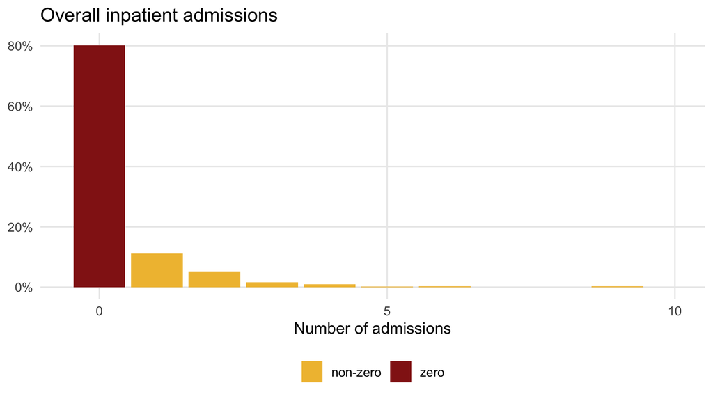

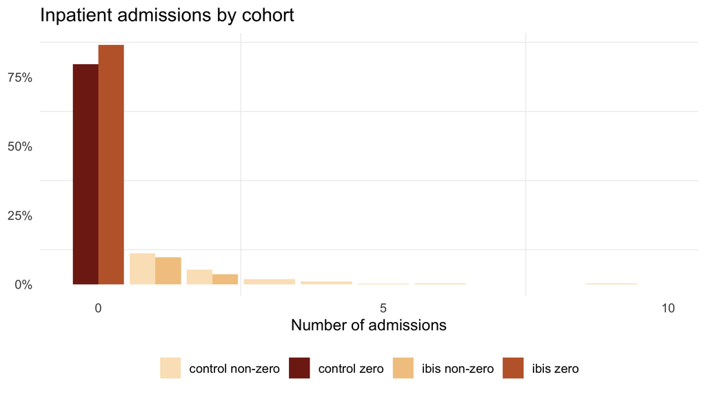

Overall

| mean | variance |
| --- | --- |
| 0.372 | 1.05 |

By cohort

| cohort | mean | variance |
| --- | --- | --- |
| control | 0.390 | 1.120 |
| ibis | 0.171 | 0.217 |

With overall variance not equal to the mean, a Poisson model is not appropriate. We consider a negative binomial model, which allows for overdispersion. But note that the dispersion parameter is a global parameter, and not adjusted for cohorts separately. That said, as it is a function of the mean, the variance given by the model *will* be adjusted for cohort.

## Covariates, multicolinearity

Perhaps surprisingly, age and chronic conditions covariates do not exhibit high multicolinearity. This means not only that there are no high pairwise correlations, but that, for example, any one of them is not explainable by the others- regressing any one on the others would results in a low R squared value.

As an illustration, with `condition count` included, the covariates are completely colinear.

Low multicolinearity is a desirable feature for generalized linear models as it results in more stable coefficient estimates.

#### Condition number

We find the condition number of the model matrix with age and other covariates. This the square root of the ratio of max and min eigen values of the correlation matrix, and is thus a ratio of the standard deviations along components of the data with max variation and min variation,

$\sqrt{\frac{\lambda_{max}}{\lambda_{min}}}$ = 2.303

As a rule of thumb, condition number > 30 is indication of high multicolinearity.

#### Correlations

Selecting covariates with low multicolinearity is also more straightforward, as simply selecting those most highly correlated with the outcome is more justifiable than in the case of high multicolinearity.

| condition | correlation |
| --- | --- |
| atrial_fibrillation | 0.2136 |
| chf | 0.2113 |
| age | 0.1311 |
| parkinsons | 0.0792 |
| chd | 0.0733 |
| copd | 0.0712 |
| lung_cancer | 0.0701 |
| anemia | 0.0641 |
| dementia | 0.0634 |
| endometrial_cancer | 0.0489 |
| urologic_cancer | 0.0484 |
| hypothyroidism | 0.0449 |
| alzheimers | 0.0446 |
| pneumonia | 0.0405 |
| kidney_disease | 0.0356 |
| hip_fracture | 0.0345 |
| heart_attack | 0.0327 |
| cataract | 0.0286 |
| anxiety | 0.0257 |
| mild_cognitive_impairment | 0.0190 |
| asthma | 0.0180 |
| hypertension | 0.0092 |
| glaucoma | 0.0069 |
| depression | 0.0011 |
| stroke | -0.0036 |
| osteoporosis | -0.0066 |
| hyperlipidemia | -0.0140 |
| hyperplasia | -0.0205 |
| diabetes | -0.0207 |
| breast_cancer | -0.0215 |
| arthritis | -0.0233 |
| prostate_cancer | -0.0425 |
| colorectal_cancer | -0.0426 |

We select `age`, `atrial_fibrillation`, and `chf`, variously in the models below.

## Admissions counts; negative binomial

We first compare intercept only and cohort models

[figure not shown]

[figure not shown]

$$\begin{aligned}
{\rm{count}}_i & \sim NB(\mu_i, \theta) \\
\log \mu_i & = \beta_0
\end{aligned}$$

| term | estimate | p.value | exp_estimate |
| --- | --- | --- | --- |
| (Intercept) | -0.99 | 0 | 0.372 |

$\theta$: 0.229

$$\begin{aligned}
{\rm{count}}_i & \sim NB(\mu_i, \theta) \\
\log \mu_i & = \beta_0 + \beta_1 \textrm{cohort}_i
\end{aligned}$$

| term | estimate | p.value | exp_estimate |
| --- | --- | --- | --- |
| (Intercept) | -0.940 | 0.000 | 0.390 |
| cohortibis | -0.827 | 0.022 | 0.437 |

$\theta$: 0.235

## Model comparison

Negative binomial with vs without `cohort` as predictor

| term | estimate | std.error | statistic | p.value |
| --- | --- | --- | --- | --- |
| (Intercept) | -0.940 | 0.088 | -10.69 | 0.000 |
| cohortibis | -0.827 | 0.362 | -2.29 | 0.022 |

## Bootstraps/predictive check, NB model for admissions counts

#### Model

$$\textrm{counts}_i \sim NB(\mu_i, \theta)$$
$$\log \mu_i = \beta_0 + \beta_1 \textrm{cohort}$$

[figure not shown]

## Observed vs expected admissions counts; negative binomial

for the **control** cohort

| inpatient_count | frequency | prevalence | expected | prob |
| --- | --- | --- | --- | --- |
| 0 | 701 | 0.797 | 699.208 | 0.795 |
| 1 | 99 | 0.112 | 102.524 | 0.117 |
| 2 | 47 | 0.053 | 39.528 | 0.045 |
| 3 | 16 | 0.018 | 18.388 | 0.021 |
| 4 | 9 | 0.010 | 9.286 | 0.011 |
| 5 | 2 | 0.002 | 4.912 | 0.006 |
| 6 | 3 | 0.003 | 2.676 | 0.003 |
| 7 | 0 | 0.000 | 1.488 | 0.002 |
| 8 | 0 | 0.000 | 0.841 | 0.001 |
| 9 | 3 | 0.003 | 0.480 | 0.001 |
| 10 | 0 | 0.000 | 0.277 | 0.000 |

For the **ibis** cohort

| inpatient_count | frequency | prevalence | expected | prob |
| --- | --- | --- | --- | --- |
| 0 | 71 | 0.866 | 72.126 | 0.880 |
| 1 | 8 | 0.098 | 7.130 | 0.087 |
| 2 | 3 | 0.037 | 1.853 | 0.023 |
| 3 | 0 | 0.000 | 0.581 | 0.007 |
| 4 | 0 | 0.000 | 0.198 | 0.002 |
| 5 | 0 | 0.000 | 0.071 | 0.001 |
| 6 | 0 | 0.000 | 0.026 | 0.000 |
| 7 | 0 | 0.000 | 0.010 | 0.000 |
| 8 | 0 | 0.000 | 0.004 | 0.000 |
| 9 | 0 | 0.000 | 0.001 | 0.000 |
| 10 | 0 | 0.000 | 0.001 | 0.000 |

## Zero inflated negative binomial

**This example for illustration only**

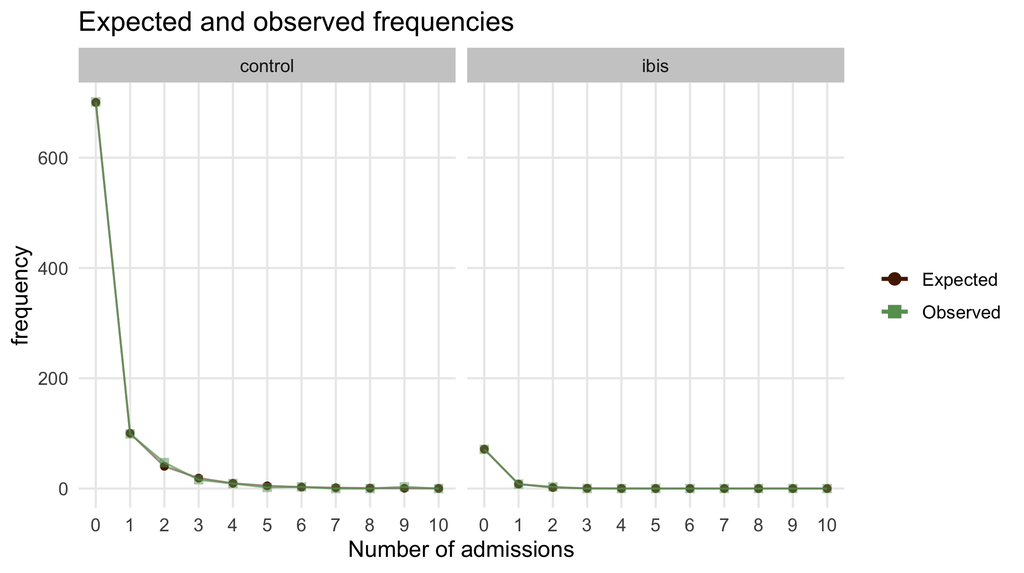

$$\begin{aligned}
\textrm{counts}_i &\sim \text{ZINB}(\pi_i, \mu_i, \theta) \\
\log\left( \frac{\pi_i}{1 - \pi_i} \right) &= \gamma_0 + \gamma_1 \, \textrm{cohort}_i \\
\log(\mu_i) &= \beta_0 + \beta_1 \, \textrm{cohort}_i
\end{aligned}$$

| term | estimate |
| --- | --- |
| count_(Intercept) | -0.685 |
| count_cohortibis | -1.082 |
| zero_(Intercept) | -1.234 |
| zero_cohortibis | -6.463 |

$\theta$: 0.331

**This example for illustration only** The coeffs are not significant, but see more models below.

Zero inflation probabilities

- control: $logit^{-1}$ -1.234 = 0.225
- ibis: $logit^{-1}$ (-1.234 + -6.463) = 4.539^{-4}

Count mean for ibis also reduced by factor of exp(-1.082) = 0.339.

## Observed vs expected admissions counts; zero inflated negative binomial

for the **control** cohort

| inpatient_count | frequency | prevalence | expected | prob |
| --- | --- | --- | --- | --- |
| 0 | 701 | 0.797 | 700.203 | 0.796 |
| 1 | 99 | 0.112 | 100.212 | 0.114 |
| 2 | 47 | 0.053 | 40.264 | 0.046 |
| 3 | 16 | 0.018 | 18.889 | 0.021 |
| 4 | 9 | 0.010 | 9.498 | 0.011 |
| 5 | 2 | 0.002 | 4.968 | 0.006 |
| 6 | 3 | 0.003 | 2.665 | 0.003 |
| 7 | 0 | 0.000 | 1.455 | 0.002 |
| 8 | 0 | 0.000 | 0.805 | 0.001 |
| 9 | 3 | 0.003 | 0.450 | 0.001 |
| 10 | 0 | 0.000 | 0.254 | 0.000 |

For the **ibis** cohort

| inpatient_count | frequency | prevalence | expected | prob |
| --- | --- | --- | --- | --- |
| 0 | 71 | 0.866 | 71.456 | 0.871 |
| 1 | 8 | 0.098 | 8.044 | 0.098 |
| 2 | 3 | 0.037 | 1.823 | 0.022 |
| 3 | 0 | 0.000 | 0.482 | 0.006 |
| 4 | 0 | 0.000 | 0.137 | 0.002 |
| 5 | 0 | 0.000 | 0.040 | 0.000 |
| 6 | 0 | 0.000 | 0.012 | 0.000 |
| 7 | 0 | 0.000 | 0.004 | 0.000 |
| 8 | 0 | 0.000 | 0.001 | 0.000 |
| 9 | 0 | 0.000 | 0.000 | 0.000 |
| 10 | 0 | 0.000 | 0.000 | 0.000 |

# More models; summary and comparisons

- zero inflated vs not
- poisson vs negative binomial distribution
- with and without `age` as a covariate.

### Zero inflated age

Two of the models include `age` as a covariate for the zero inflation part of the model. We highlight those here. The full summary of all the models follows.

Zero inflated Poisson with age zero inflation

| term | component | estimate | p.value |
| --- | --- | --- | --- |
| (Intercept) | count | 1.7435 | 0.0000 |
| cohortibis | count | -0.7188 | 0.0265 |
| age | count | -0.0246 | 0.0001 |
| chf | count | 0.4645 | 0.0013 |
| atrial_fibrillation | count | 0.4299 | 0.0030 |
| (Intercept) | zero | 4.2559 | 0.0000 |
| age | zero | -0.0483 | 0.0000 |

Zero inflated negative binomial with age zero inflation

| term | component | estimate | p.value |
| --- | --- | --- | --- |
| (Intercept) | count | 1.2582 | 0.0722 |
| cohortibis | count | -0.6441 | 0.0640 |
| age | count | -0.0287 | 0.0017 |
| chf | count | 0.7563 | 0.0002 |
| atrial_fibrillation | count | 0.7098 | 0.0004 |
| Log(theta) | count | -0.3909 | 0.2399 |
| (Intercept) | zero | 4.2462 | 0.0000 |
| age | zero | -0.0656 | 0.0000 |

### Coefficients for all models

Poisson and negative binomial; no zero inflation

| model | (Intercept) | cohortibis | chf | atrial_fibrillation | age |
| --- | --- | --- | --- | --- | --- |
| Pois1 | -1.31 | -0.754 | 0.671 | 0.697 | NA |
| Pois2 | -1.52 | -0.765 | 0.662 | 0.674 | 0.0030 |
| NB1 | -1.32 | -0.644 | 0.676 | 0.689 | NA |
| NB | -1.04 | -0.616 | 0.703 | 0.727 | -0.0042 |

Poisson and negative binomial; no zero inflation - long format with p-values

| term | estimate | pval | model |
| --- | --- | --- | --- |
| (Intercept) | -1.3142 | 0.0000 | Pois1 |
| cohortibis | -0.7539 | 0.0059 | Pois1 |
| chf | 0.6713 | 0.0000 | Pois1 |
| atrial_fibrillation | 0.6968 | 0.0000 | Pois1 |
| (Intercept) | -1.5165 | 0.0000 | Pois2 |
| cohortibis | -0.7655 | 0.0053 | Pois2 |
| age | 0.0030 | 0.5509 | Pois2 |
| chf | 0.6621 | 0.0000 | Pois2 |
| atrial_fibrillation | 0.6739 | 0.0000 | Pois2 |
| (Intercept) | -1.3199 | 0.0000 | NB1 |
| cohortibis | -0.6439 | 0.0641 | NB1 |
| chf | 0.6763 | 0.0009 | NB1 |
| atrial_fibrillation | 0.6891 | 0.0006 | NB1 |
| (Intercept) | -1.0430 | 0.0496 | NB |
| cohortibis | -0.6159 | 0.0782 | NB |
| age | -0.0042 | 0.5893 | NB |
| chf | 0.7028 | 0.0006 | NB |
| atrial_fibrillation | 0.7274 | 0.0005 | NB |

Zero inflated Poisson and negative binomial.

| term | component | estimate | p.value | model |
| --- | --- | --- | --- | --- |
| (Intercept) | count | 0.0868 | 0.4623 | ZIP1 |
| cohortibis | count | -0.7174 | 0.0274 | ZIP1 |
| chf | count | 0.3070 | 0.0297 | ZIP1 |
| atrial_fibrillation | count | 0.2890 | 0.0388 | ZIP1 |
| (Intercept) | zero | 0.8746 | 0.0000 | ZIP1 |
| (Intercept) | count | -1.3200 | 0.0000 | ZINB1 |
| cohortibis | count | -0.6429 | 0.0708 | ZINB1 |
| chf | count | 0.6763 | 0.0009 | ZINB1 |
| atrial_fibrillation | count | 0.6894 | 0.0005 | ZINB1 |
| Log(theta) | count | -1.2508 | 0.0000 | ZINB1 |
| (Intercept) | zero | -9.8760 | 0.8917 | ZINB1 |
| (Intercept) | count | 0.8308 | 0.0553 | ZIP2 |
| cohortibis | count | -0.6484 | 0.0495 | ZIP2 |
| age | count | -0.0109 | 0.0759 | ZIP2 |
| chf | count | 0.3806 | 0.0095 | ZIP2 |
| atrial_fibrillation | count | 0.3694 | 0.0118 | ZIP2 |
| (Intercept) | zero | 0.8842 | 0.0000 | ZIP2 |
| (Intercept) | count | -1.0428 | 0.0467 | ZINB2 |
| cohortibis | count | -0.6159 | 0.0872 | ZINB2 |
| age | count | -0.0042 | 0.5897 | ZINB2 |
| chf | count | 0.7028 | 0.0008 | ZINB2 |
| atrial_fibrillation | count | 0.7274 | 0.0006 | ZINB2 |
| Log(theta) | count | -1.2521 | 0.0000 | ZINB2 |
| (Intercept) | zero | -9.0452 | 0.8551 | ZINB2 |
| (Intercept) | count | 1.7435 | 0.0000 | ZIP3 |
| cohortibis | count | -0.7188 | 0.0265 | ZIP3 |
| age | count | -0.0246 | 0.0001 | ZIP3 |
| chf | count | 0.4645 | 0.0013 | ZIP3 |
| atrial_fibrillation | count | 0.4299 | 0.0030 | ZIP3 |
| (Intercept) | zero | 4.2559 | 0.0000 | ZIP3 |
| age | zero | -0.0483 | 0.0000 | ZIP3 |
| (Intercept) | count | 1.2582 | 0.0722 | ZINB3 |
| cohortibis | count | -0.6441 | 0.0640 | ZINB3 |
| age | count | -0.0287 | 0.0017 | ZINB3 |
| chf | count | 0.7563 | 0.0002 | ZINB3 |
| atrial_fibrillation | count | 0.7098 | 0.0004 | ZINB3 |
| Log(theta) | count | -0.3909 | 0.2399 | ZINB3 |
| (Intercept) | zero | 4.2462 | 0.0000 | ZINB3 |
| age | zero | -0.0656 | 0.0000 | ZINB3 |

### Fit

| model | logLik | df | AIC | BIC |
| --- | --- | --- | --- | --- |
| Pois1 | -839 | 4 | 1685 | 1705 |
| Pois2 | -839 | 5 | 1687 | 1711 |
| NB1 | -706 | 5 | 1421 | 1445 |
| NB2 | -705 | 6 | 1423 | 1452 |
| ZIP1 | -742 | 5 | 1494 | 1518 |
| ZINB1 | -706 | 6 | 1423 | 1452 |
| ZIP2 | -740 | 6 | 1493 | 1522 |
| ZINB2 | -705 | 7 | 1425 | 1459 |
| ZIP3 | -726 | 7 | 1467 | 1501 |
| ZINB3 | -698 | 8 | 1412 | 1451 |

# Bayesian zero inflated Poisson regression

Bayesian models often offer some advantages. We get an entire distribution for every parameter modeled-not just point estimates and confidence intervals. We can also get distributions for any statistic.

We consider just one model here.

#### Model

$$\begin{aligned}
\textrm{counts}_i & \sim ZIP(\pi_i, \mu_i) \\
\log \mu_i & = \beta_0 + \beta_1 \textrm{cohort}_i + \beta_2\textrm{chf}_i + \beta_3\textrm{atrial\fibrillation}_i\\
\log \frac{\pi_i}{1 - \pi_i} & = \gamma_0 \\
\end{aligned}$$

## Model results; compare frequentist ZIP model

**Bayes**

| component | term | Estimate | Est.Error | Q2.5 | Q97.5 |
| --- | --- | --- | --- | --- | --- |
| count | Intercept | 0.118 | 0.111 | -0.105 | 0.330 |
| zero | zi_Intercept | 0.938 | 0.110 | 0.716 | 1.149 |
| count | cohortibis | -0.517 | 0.271 | -1.057 | 0.003 |
| count | chf | 0.286 | 0.133 | 0.026 | 0.549 |
| count | atrial_fibrillation | 0.259 | 0.133 | 0.000 | 0.519 |

**Frequentist**

[output not shown]

## Posterior distributions

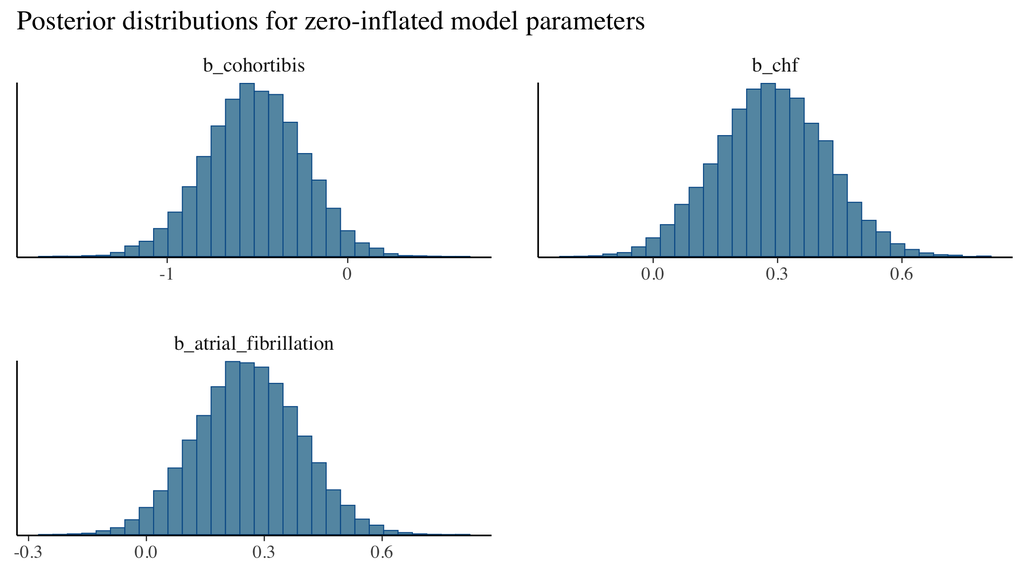

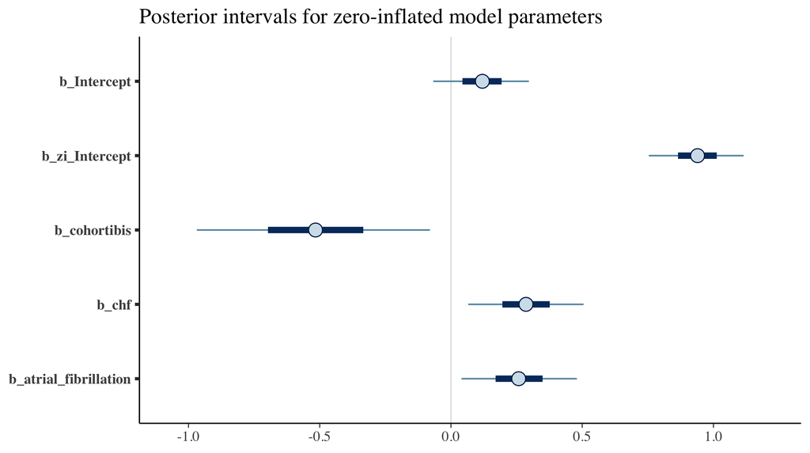

100 draws from the posterior predictive distribution

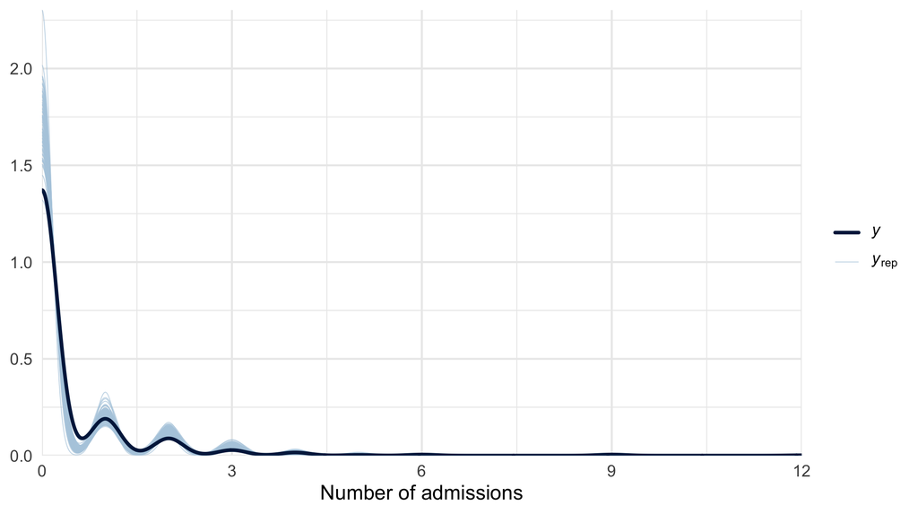

## Post predictive checks

We can check how the distribution of proportions for different values of `inpatient_count` compares with those in the data.

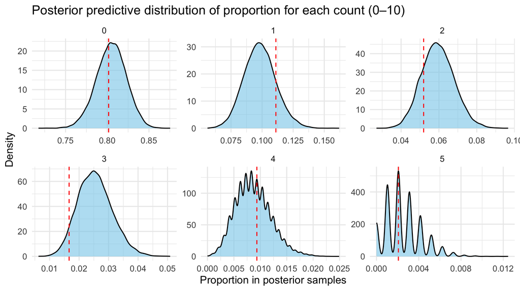

# Math notes

## Linear models

Continuous response $Y$ (eg, heart rate) as a function of predictors; aka **covariates**, $X_j$ (eg, cholesterol, smoker)

$$Y \sim N(\mu , \sigma^2)$$
where the conditional mean is a linear function of the predictors

$$\mu = E(Y |X ) = \beta_0 + \sum_{j=1}^p \beta_j X_j = X \boldsymbol{\beta}$$

- $\beta_j$ are estimated by minimizing the sum of squares errors,
  $$\sum_i (y_i - (\beta_0 - \sum_j \beta_j x_{ij}))^2 = ||\mathbf{y} - \mathbf{X}\boldsymbol{\beta}||^2_2$$
- We can interpret the coefficients directly as effect sizes.

## Generalized linear models

We model *a function of* the conditional mean as a linear function

$$g(\mu ) = \beta_0 + \sum_{j=1}^p \beta_j X_j = X \boldsymbol{\beta}$$

$g$ is called a *link* function.

#### Example: Logistic regression

$$Y \sim \textrm{Bernoulli}(\mu )$$
Coin toss with probability $\mu$ of heads, $1 - \mu$ of tails.

$$g(\mu ) = \rm{logit} \ \mu := \log \left(\frac{\mu}{1 - \mu}\right) = X \boldsymbol{\beta}$$

$$\mu = \rm{logit}^{-1}(X \boldsymbol{\beta})$$

## Likelihood

To find $\beta_j$, we typically maximize the (log) likelihood function.

For logistic regression, with $n$ independent observations $y_i =$ 0 or 1, the joint probability is

$$p({\bf{y}} | X_i) = \mu_i^{y_i} (1 - \mu_i)^{1 - y_i}$$

The log likelihood is then

$$logLik(\boldsymbol{\beta}) = \sum_{i=1}^n y_i \log(\mu_i) + (1 - y_i)\log (1 - \mu_i)$$

Where are the $\beta$’s?

Recall that $\mu_i = \rm{logit}^{-1}(X_i \boldsymbol{\beta})$)

## Poisson regression

Counts $Y$ modeled as

$$p(Y = y; \mu) = \frac{\mu^y e^{-\mu }}{y!}$$
with “canonical” link

$$g(\mu ) = \log(\mu ) = X \boldsymbol{\beta}$$

Likelihood

$$logLik(\boldsymbol{\boldsymbol{\beta}}) = \sum_{i=1}^n \left( y_i \log \mu_i - \mu_i - \log (y_i!) \right)$$

## Fun fact

> For a linear model, the minimum sum of squares estimate is the same as the maximum likelihood estimate.

Models

- Zero inflated Poisson regression
- Zero inflated negative binomial regression
- Bayes versions of the above

## Negative binomial distribution

Often used on *overdispersed* data: $\mu < \sigma^2$.

$$p(Y = y; \mu, \theta) = \binom{y + \theta - 1}{\theta} \left(\frac{\mu}{\mu + \theta}\right)^y \left(\frac{\theta}{\mu + \theta}\right)^\theta$$

- *Dispersion* parameter $\theta > 0$; fixed- does not vary with covariates like $\mu$.
- $\theta$ is estimated by the model

**Conditional mean** $E(Y|X) = \mu$. We again model with log link

$$\log \mu = X \boldsymbol{\beta}$$

**Variance**

$$Var(Y|X) = \mu + \mu^2/\theta$$

$\theta$ part of the model fit - unlike $\sigma^2$ in linear regression.

## Zero inflated Poisson regression

Define $Z \sim Bernoulli(\pi)$ - a coin flip with probability $\pi$ of heads.

$$Y = \begin{cases}
0 & \text{if} \ Z = 1 \\
\sim Pois(\mu) & \text{if} \ Z = 0
\end{cases}$$

- $Z$ models the **zero-inflated** portion - the “extra” zeros.
- The additional count data, including zeros, is modeled with the Poisson distribution with mean $\mu$.

$$p(Y = y; \mu, \pi) = \begin{cases}
\pi + (1 - \pi) e^{-\mu} & \text{if } y = 0 \\
(1 - \pi) \frac{\mu^y e^{-\mu}}{y!} & \text{if } y > 0
\end{cases}$$

(Recall Poisson distribution is $P(y; \mu) = \mu^y e^{-\mu}/y!$)

- $\log \frac{\pi}{1 -\pi} =$ linear function of some covariates
- $\log(\mu) =$ linear function of some covariates

## Zero inflated Poisson regression

We again estimate the coefficients using log likelihood.

$$p(Y = y; \mu, \pi) = \begin{cases}
\pi + (1 - \pi) e^{-\mu} & \text{if } y = 0 \\
(1 - \pi) \frac{\mu^y e^{-\mu}}{y!} & \text{if } y > 0
\end{cases}$$

#### Likelihood function

$$\begin{align*}
logLik(\mathbf{\beta}, \mathbf{\gamma}) = \sum_{i=1}^n \Big(& \mathbf{1}_{\{y_i = 0\}} \cdot \log \left( \pi_i + (1 - \pi_i) e^{-\mu_i} \right) \\
& + \mathbf{1}_{\{y_i > 0\}} \cdot \left( \log(1 - \pi_i) + y_i \log(\mu_i) - \mu_i - \log(y_i!) \right) \Big)
\end{align*}$$

## Bayesian statistical modeling

#### Starts with Bayes’ Rule

The conditional probability of $B_k$ given $A$ is

$$\begin{aligned}
P(B_k \ | \ A) & = \frac{P(A \ | \ B_k) P(B_k)}{P(A)} \\
& = \frac{P(A \ | \ B_k) P(B_k)}{\sum_i P(A \ | \ B_i) P(B_i)}
\end{aligned}$$

where $A$ and $B_j$ are events with $B_j$ a partition of the sample space. The vertical bar indicates conditional probability

#### The standard disease/positive test example

$$P(D | +) = \frac{P(+ | D) \ P(D)}{P(+ | D) P(D) + P(+ | \bar{D}) P(\bar{D})}$$

## Bayes’ Rule for probability *densities* for model parameters

$$p(\boldsymbol{\theta} | y, X) = \frac{p(\boldsymbol{\theta}) p(y | \boldsymbol{\theta}, X)}{\int p(y | \boldsymbol{\theta}, X) p(\boldsymbol{\theta}) d\boldsymbol{\theta}}$$

- *random vector* of model parameters $\boldsymbol{\theta}$ (our $\beta$’s and $\gamma$’s)
- *fixed* predictor data $X$ and response data $y$
- $p(\boldsymbol{\theta})$ is the *prior distribution* for the parameters
- $p(y | \boldsymbol{\theta}, X)$ is the *likelihood* of the data given the parameters $\theta$ - same as the likelihood function in frequentist statistics.
- $p(\theta | x)$ is the *posterior* distribution for the parameters $\theta$.

The denominator is an integration over the parameter space; typically intractable $\Rightarrow$ Markov Chain Monte Carlo (MCMC) methods to approximate the posterior distribution.

## Posterior predictive distribution

Once you have the $\theta$ posterior, you can compute the posterior predictive distributions of a new observation $x_0$, given the data $X$.

$$\begin{align*}
p(x_0|X) & = \int p(x_0, \theta | X)\, d\theta \\
\\
& = \int p(x_0| \theta, X) \, p(\theta |X) , d\theta \\
\\
& = \int p(x_0|\theta) \, p(\theta | X) \, d\theta\\
\end{align*}$$

Can also get a distribution for any statistic of interest.

## Bayesian inference

- Parameters are regarded as random variables, data fixed
- We get an entire distribution for every parameter, and hence for any statistic we wish to compute
- No p-values, no hypothesis testing!

## Example

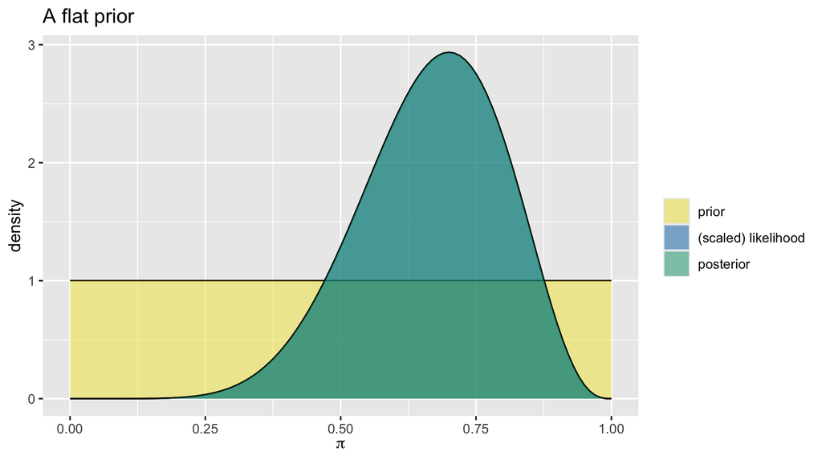

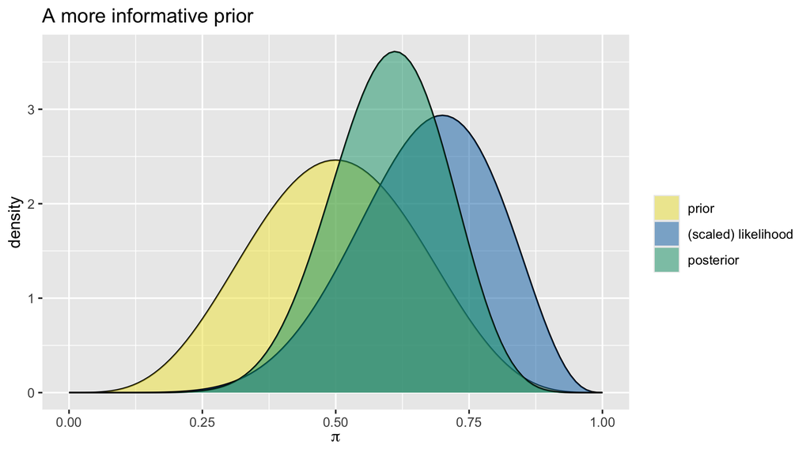

By contrast, our maximum likelihood estimate of $\pi$ would be the peak of the likelihood, which is the same as the posterior for flat prior.